# R Notebook

```r
library(rpart)
library(rpart.plot)
library(tidyverse)
library(tidyverse)
titanic_set <- read_csv('data/titanic_decision_tree_data.csv')
shuffle_index <- sample(1:nrow(titanic_set))

# shuffle the data so class order isn't in order - need this for training/testing split later on
titanic_set <- titanic_set[shuffle_index, ]
```

```r
titanic_clean <- titanic_set %>%
  filter(survived %in% c(0,1)) %>%
# Convert to factor level
    mutate(sex = as.factor(sex),
           age_status = as.factor(if_else(age <= 16, "child", "adult")),
         class = factor(pclass, levels = c(3,2,1), labels = c("Lower", "Middle", "Upper")),
           survived_flag = factor(survived, levels = c(0,1), labels = c("No", "Yes")),
           port_embarkation = as.factor(embarked)) %>%
  select(sex, age_status, class, port_embarkation, sib_sp, parch, survived_flag) %>%
  na.omit()
```

1.2 Question 2

Have a look at your data and create some plots to ensure you know what you’re working with before you begin. Write a summary of what you have found in your plots. Which variables do you think might be useful to predict whether or not people are going to die? Knowing this before you start is the best way to have a sanity check that your model is doing a good job.

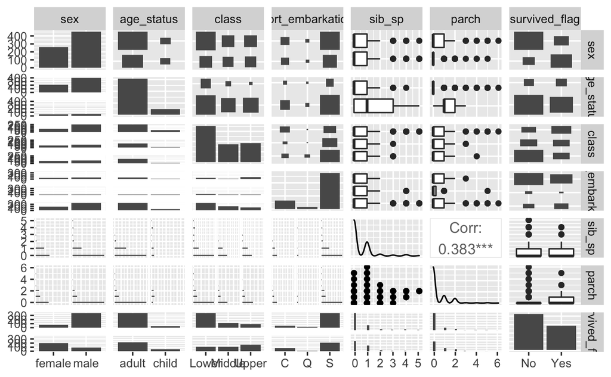

just from this graph all apart from slib_sp and parch doesn’t seem to have a big impact on survided. others all seem to.

1.3 Question 3

Now you can start to build your model. Create your testing and training set using an appropriate split. Check you have balanced sets. Write down why you chose the split you did and produce output tables to show whether or not it is balanced. [Extra - if you want to force balanced testing and training sets, have a look at the stratified() function in package splitstackshape (you can specify multiple variables to stratify on by passing a vector of variable names to the group argument, and get back testing and training sets with argument bothSets = TRUE)]

```r
n_data <- nrow(titanic_clean)

test_index <- sample(1:n_data, size = n_data*0.2)


titanic_test  <- slice(titanic_clean, test_index)


titanic_train <- slice(titanic_clean, -test_index)
```

```r
titanic_test %>%
 janitor::tabyl(survived_flag)
```

```
 survived_flag  n  percent
            No 79 0.556338
           Yes 63 0.443662
```

```r
titanic_train %>%
 janitor::tabyl(survived_flag)
```

```
 survived_flag   n   percent
            No 345 0.6052632
           Yes 225 0.3947368
```

I did 80% training and 20% for testing and the output looks good, very similar but not the same.

1.4 Question 4

Create your decision tree to try and predict survival probability using an appropriate method, and create a decision tree plot.

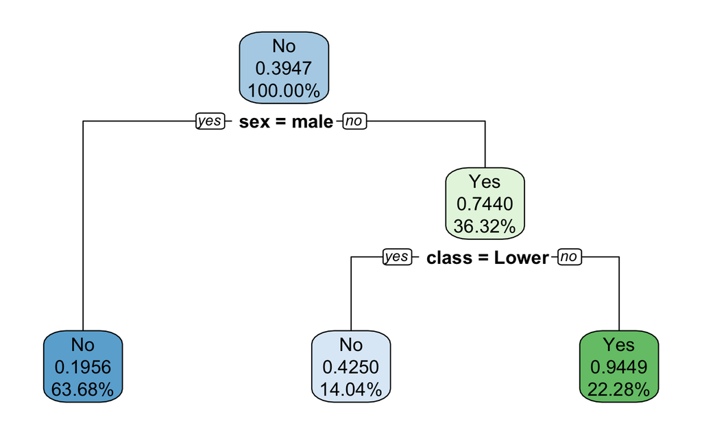

```r
titanic_fit <- rpart(
  formula = survived_flag ~ .,
  data = titanic_train,
  method = 'class'
)

rpart.plot(titanic_fit,
           yesno = 2,
           fallen.leaves = TRUE,
           faclen = 6,
           digits = 4)
```

1.5 Question 5

Write down what this tells you, in detail. What variables are important? What does each node tell you? Who has the highest chance of surviving? Who has the lowest? Provide as much detail as you can.

[output not shown]

1.6 Question 6

Test and add your predictions to your data. Create a confusion matrix. Write down in detail what this tells you for this specific dataset.

```r
library(modelr)
library(yardstick)
```

```r
titanic_test_pred <- titanic_test %>%
  add_predictions(titanic_fit, type = 'class')
```

```r
conf_mat<- titanic_test_pred %>%
  conf_mat(truth = survived_flag,
           estimate = pred)
conf_mat
```

```
          Truth
Prediction No Yes
       No  77  35
       Yes  2  28
```

```r
(77+28)/(77+35+2+28)
```

```
[1] 0.7394366
```

it’s 73.94% current, for the mistakes they make, most of them are false negative(predicited No but they survived)